# Post Goals:

1. Introduction to One-Way ANOVA.
2. Data Structure, Assumptions and Hypothesis.
3. Sources of Variability.
4. ANOVA Table and F-test.

# Introduction to One-Way ANOVA.

**The basics**

- This goal of this procedure is to find statistically significant differences between multiple population means.
- The independent variable is a categorical variable that takes two or more values.
- The response (dependent) variable is numerical.
- The independent variable defines the group (subpopulations).
- Examples:
  - Annual gross income of americans based on their political party.
  - Bupropion XL prescription rates based on state.

# Data Structure, Assumptions and Hypothesis.

**The basics on the Data Structure**

- The independent variable is categorical and each category is called a level.
- The data for an ANOVA analysis typically contains a column for the independent variable and then a column with its corresponding numeric dependent variable value.
- When each category has equal number of instances, then this is called a balanced design.
- When each category has unequal number of instances, then this is an unbalanced design.
- Assumptions
  - Samples for each cateogry are randomly selected from their respective populations.
  - The samples are independent of one another.
  - The populations are normally distributed.
  - The population for all the categories have the same population variance (homoscedasticity).
  - $$\sigma_1=\sigma_2=\sigma_3=\sigma_4=\sigma$$ where $\sigma$ represents the standard deviation of all the categorical populations.
  - Leves test is a common test used to determine if the data have equal population variances (homoscedasticity).
  - Boxplots are also used to evaluate variance.
- Hypothesis test:$$\begin{aligned} &H_0\colon\mu_1=\mu_2=\mu_3=\mu_4\\ \text{against }&H_a\colon\text{there exists some difference in the $\mu_j$'s}\end{aligned}$$
- Rejecting the $H_0$ does not reveal which difference exists, so a post hoc test would need to be completed.
- The F-Distribution is used to determine if a there is sufficient evidence to accept or reject the null hypothesis.
- The R programming language will be used to carry out these calculations.

## Load Data

```r
grain.data <- read.csv("static/data/thiamin.csv")
str(grain.data)
```

```
'data.frame':	24 obs. of  2 variables:
 $ grain  : chr  "Wheat" "Wheat" "Wheat" "Wheat" ...
 $ thiamin: num  5.2 4.5 6 6.1 6.7 5.8 6.5 8 6.1 7.5 ...
```

## Inspect the categorical data

```r
grain.data$grain <- factor(grain.data$grain)
attach(grain.data)
levels(grain.data$grain)
```

1. 'Barley'

2. 'Maize'

3. 'Oat'

4. 'Wheat'

## Obtain summary statistics

```r
aggregate(thiamin~grain, FUN=mean) # obtain sample means for each sample defined by 'grain'
aggregate(thiamin~grain, FUN=sd) # obtain sample st. devs. for each sample defined by 'grain'
aggregate(thiamin~grain, FUN=length) # obtain sample sizes for each sample defined by 'grain'
```

A data.frame: 4 × 2

| grain <fct> | thiamin <dbl> |
| --- | --- |
| Barley | 6.600000 |
| Maize | 5.500000 |
| Oat | 6.983333 |
| Wheat | 5.716667 |

A data.frame: 4 × 2

| grain <fct> | thiamin <dbl> |
| --- | --- |
| Barley | 0.9507891 |
| Maize | 0.6693280 |
| Oat | 1.0419533 |
| Wheat | 0.7678976 |

A data.frame: 4 × 2

| grain <fct> | thiamin <int> |
| --- | --- |
| Barley | 6 |
| Maize | 6 |
| Oat | 6 |
| Wheat | 6 |

## Calculate test statistics

```r
ybar <- mean(thiamin); ybar
var.y <- var(thiamin); var.y
```

6.2

1.04869565217391

## Evaluate Variance using BoxPlot

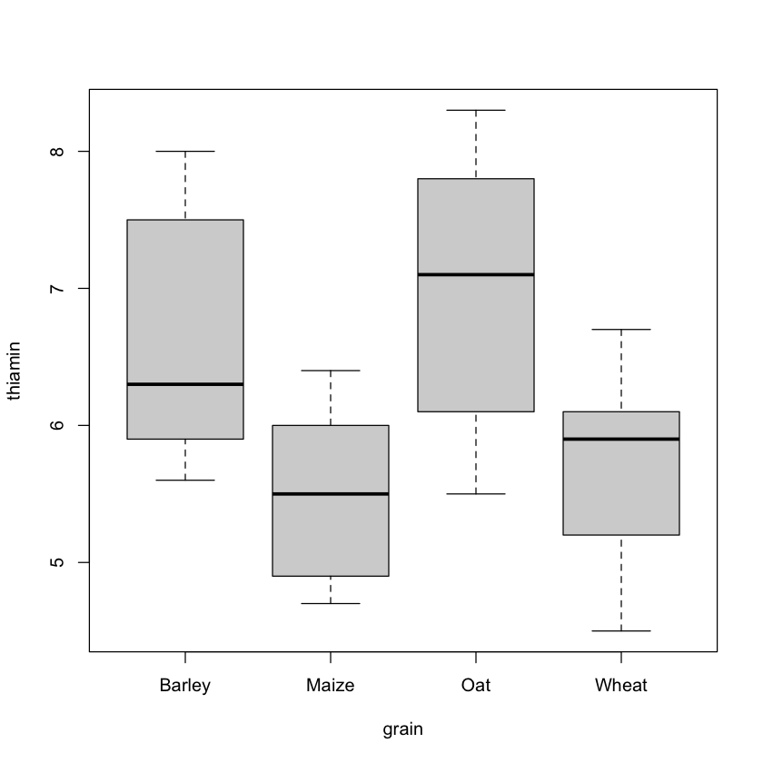

```r
boxplot(thiamin~grain)
```

# Sources of Variability.

**The basics**

- The ANOVA relies on the F-test.
- The F-test tests the partition, or decomposition, of the total variability.
- The variability in a sample can be tested using the sample variance, the sample standard deviation, the sample inerquartile range, the sample range.
- In the ANOVA, the variability will be represented as the **sums of square deviations**.
- **The Total sums of squares SST**: represents the total variability among all the observations without splitting the data into groups.
- **The Total sums of squares SST**: in the ANOVA is also concerned with the sum of square deviations of each observation in the sample from the overall mean
- The SST measures deviations of all observations from the overall mean $\bar{y}$
- The degrees of freedom for the SST is 𝑁−1
- The total sum of squares is defined as $$SST=\sum_{i,j}(y_{i,j}-\bar y)^2$$
- **Mean of square deviations**: The overall sample variance is just the sum of square deviations divided by the degrees of freedom and is defined as: $$s^2=\frac{SST}{N-1}\quad\Leftrightarrow\quad SST=(N-1)s^2$$
- The $s^2$ is also the mean of square deviations.
- **The sum of square deviations within the ith sample**: $$SS_i=\sum_{j=1}^{n_i}(y_{i,j}-\bar y_i)^2$$
- **The sample variance of the ith sample**: is the sum of all thd square deviations of each observation from their respective group mean and is defined as $$s_i^2=\frac{SS_i}{n_i-1}\quad\Leftrightarrow\quad SS_i=(n_i-1)s_i^2$$
- **The between groups sum of square deviations**: is the variability between the sample means around the Y (response) variable. $$SSB=\sum_{i,j}(\bar y_i-\bar y)^2=\sum_i n_i(\bar y_i-\bar y)^2$$
- **The within group sum of square SSW**: is the variability between the sample means around the Y (response) variable. $$SSW=SS_1+SS_2+\dotsb+SS_k=(n_1-1)s_1^2+(n_2-1)s_2^2+\dotsb+(n_k-1)s_k^2$$
- The decomposition of the SST is $$SST=SSW+SSB$$
- The variability in the sample can be split into the variability between groups **SSB** and the variability in observations within each sample **SSW**.
- The **SSB** is the variability explained by the presence of the independent variable.
- The **SSW** is the variability that is left unexplained by the presence of the independent variable.
- The degrees of freedom for each of these sum of square deviations is $$df_T=N-1,\quad df_B=k-1,\quad df_W=N-k$$.

## Calculate Total Sum of Squares

```r
y <- thiamin # so we don't have to keep typing out 'thiamin'
SST <- sum( (y-ybar)^2 ); SST
```

24.12

## Calculate the mean of square deviations

```r
N <- length(y); N
SST/(N-1) # same as var(y)
var(y)
```

24

1.04869565217391

1.04869565217391

## Calculate SST

```r
SST <- sum( (y-ybar)^2 ); SST
N <- length(y); N
dfT <- N-1; dfT
```

24.12

24

23

## Calcualte the SSB

```r
means <- aggregate(thiamin~grain, FUN=mean)[,2]
k <- 4
dfB <- k-1
SSB <- sum( 6*(means-ybar)^2 );SSB
```

8.98333333333333

## Calculate the SSW

```r
dfW <- N-k
SSW <- SST-SSB
SSW
```

15.1366666666667

## Calculate SSW using vars

```r
vars <- aggregate(thiamin~grain, FUN=var)[,2]
sum( 5*vars ) # same as SSW
```

15.1366666666667

# ANOVA Table and F-test.

## Calculate Mean Square Deviations

```r
MSW <- SSW / dfW; MSW
MSB <- SSB / dfB; MSB
```

0.756833333333333

2.99444444444444

## Calculate the F.statistic

```r
f.stat <- MSB/MSW; f.stat
```

3.95654407986493

## Determine if this is significance at $\alpha = 0.05$

```r
f.crit <- qf(0.05, dfB, dfW, lower.tail=FALSE); f.crit
```

3.09839121214078

```r
pf(f.stat, dfB, dfW, lower.tail=FALSE)
```

0.0229342124924422

## Reject $H_0$